# AllLife Bank – Personal Loan Prediction Case Study

## Problem Definition

AllLife Bank is facing a business challenge where:

- Most customers are liability customers (deposit holders)
- Very few customers are asset customers (loan borrowers)

The bank wants to increase personal loan customers without losing depositors

Although a previous marketing campaign achieved a 9% conversion rate, the bank wants to improve this rate further by targeting the right customers instead of contacting everyone.

### Core Problem

The bank does not know which customers are most likely to accept a personal loan offer.

### Problem Statement

To build a predictive model that identifies liability customers who are most likely to purchase a personal loan, so that marketing efforts can be more focused and effective.

### Objectives of the Study

1. Predict whether a customer will accept a personal loan
2. Identify key customer attributes influencing loan acceptance
3. Segment customers to target high-probability customers
4. Improve marketing campaign efficiency and success rate

### Questions to Be Answered (EDA Perspective)

During Exploratory Data Analysis, we aim to answer the following questions:

### 1. Customer Behavior & Loan Acceptance

a. What percentage of customers accepted the personal loan?

b. How does income affect personal loan acceptance?

c. Does education level influence loan purchase decisions?

d. Are customers with higher credit card spending (CCAvg) more likely to take a loan?

e. Does having a mortgage impact personal loan acceptance?

### 2. Demographic Questions

a. Which age group is more likely to buy a loan?

b. Does family size influence loan purchase?

c. Is professional experience related to loan acceptance?

### 3. Banking Relationship Factors

a. Do customers with a CD account show higher loan acceptance?

b. Is there a relationship between securities account ownership and loan purchase?

c. Do online banking users respond better to loan campaigns?

d. Does using a credit card from another bank impact loan acceptance?

e. Does higher credit card spending (CCAvg) increase loan probability?

f. Do customers with mortgages show higher interest in personal loans?

g. Do customers with securities accounts show higher conversion?

### 4. Customer Segmentation

a. Can customers be grouped into meaningful segments based on income, age, education, and spending?

b. Which customer segments have the highest probability of accepting personal loans?

### 5. Channel Usage Questions

Are online banking users more likely to accept loans?

## Dataset Description

### Dataset Overview:

The dataset contains customer information collected by AllLife Bank during a personal loan marketing campaign to analyze and predict customer loan acceptance behavior.

### 1. Customer ID:

A unique identifier assigned to each customer, used only for identification purposes and not for analysis.

### 2. Age:

Represents the customer’s age in completed years and helps understand the life stage and financial maturity of the customer.

### 3. Experience:

Indicates the number of years of professional experience, which reflects job stability and earning potential.

### 4. Income:

Shows the annual income of the customer measured in thousand dollars and is a key factor influencing loan eligibility.

### 5. ZIP Code:

Represents the customer’s residential location and is mainly used for reference rather than predictive analysis.

### 6. Family:

Denotes the size of the customer’s family, which may affect financial responsibilities and loan needs.

### 7. CCAvg:

Indicates the average monthly credit card spending in thousand dollars, providing insight into customer spending behavior.

### 8. Education:

Represents the education level of the customer, categorized as (1) Undergrad, (2) Graduate, and (3) Advanced/Professional, which may influence income and financial awareness.

### 9. Mortgage:

Shows the value of any existing home mortgage in thousand dollars, indicating long-term financial commitments.

### 10. Personal_Loan:

The target variable that indicates whether the customer accepted the personal loan offered during the previous campaign.

### 11. Securities_Account:

Indicates whether the customer holds a securities account with the bank, reflecting investment behavior.

### 12. CD_Account:

Shows whether the customer has a certificate of deposit account, indicating long-term savings and customer loyalty.

### 13. Online:

Represents whether the customer uses internet banking facilities, reflecting digital engagement.

### 14. CreditCard:

Indicates whether the customer uses a credit card issued by another bank, showing involvement with competing financial institutions.

The dataset is used to perform exploratory data analysis, visualization, and predictive modeling to identify customers with a higher probability of accepting personal loans.

```python
#importing necessary libraries
import pandas as pd
import numpy as np
import matplotlib.pyplot as plt
import seaborn as sns
import warnings
warnings.filterwarnings('ignore')
```

## Importing Dataset

```python
#option:1
# from google.colab import drive
# drive.mount('/content/drive')
```

```python
# df = pd.read_csv('/content/drive/MyDrive/Colab Notebooks/Loan_Modelling (1).csv')
# df.head()
```

```python
#option:2
#Reading dataset
df=pd.read_csv('/content/Loan_Modelling (1).csv')
df.head(5) #fetching First Five rows
```

|  | ID | Age | Experience | Income | ZIPCode | Family | CCAvg | Education | Mortgage | Personal_Loan | Securities_Account | CD_Account | Online | CreditCard |
| --- | --- | --- | --- | --- | --- | --- | --- | --- | --- | --- | --- | --- | --- | --- |
| 0 | 1 | 25 | 1 | 49 | 91107 | 4 | 1.6 | 1 | 0 | 0 | 1 | 0 | 0 | 0 |
| 1 | 2 | 45 | 19 | 34 | 90089 | 3 | 1.5 | 1 | 0 | 0 | 1 | 0 | 0 | 0 |
| 2 | 3 | 39 | 15 | 11 | 94720 | 1 | 1.0 | 1 | 0 | 0 | 0 | 0 | 0 | 0 |
| 3 | 4 | 35 | 9 | 100 | 94112 | 1 | 2.7 | 2 | 0 | 0 | 0 | 0 | 0 | 0 |
| 4 | 5 | 35 | 8 | 45 | 91330 | 4 | 1.0 | 2 | 0 | 0 | 0 | 0 | 0 | 1 |

```python
#fetching last 5 rows
df.tail(5)
```

|  | ID | Age | Experience | Income | ZIPCode | Family | CCAvg | Education | Mortgage | Personal_Loan | Securities_Account | CD_Account | Online | CreditCard |
| --- | --- | --- | --- | --- | --- | --- | --- | --- | --- | --- | --- | --- | --- | --- |
| 4995 | 4996 | 29 | 3 | 40 | 92697 | 1 | 1.9 | 3 | 0 | 0 | 0 | 0 | 1 | 0 |
| 4996 | 4997 | 30 | 4 | 15 | 92037 | 4 | 0.4 | 1 | 85 | 0 | 0 | 0 | 1 | 0 |
| 4997 | 4998 | 63 | 39 | 24 | 93023 | 2 | 0.3 | 3 | 0 | 0 | 0 | 0 | 0 | 0 |
| 4998 | 4999 | 65 | 40 | 49 | 90034 | 3 | 0.5 | 2 | 0 | 0 | 0 | 0 | 1 | 0 |
| 4999 | 5000 | 28 | 4 | 83 | 92612 | 3 | 0.8 | 1 | 0 | 0 | 0 | 0 | 1 | 1 |

```python
#randomly picking 5 rows
df.sample(5)
```

|  | ID | Age | Experience | Income | ZIPCode | Family | CCAvg | Education | Mortgage | Personal_Loan | Securities_Account | CD_Account | Online | CreditCard |
| --- | --- | --- | --- | --- | --- | --- | --- | --- | --- | --- | --- | --- | --- | --- |
| 3507 | 3508 | 50 | 23 | 83 | 91791 | 1 | 2.67 | 2 | 0 | 0 | 0 | 1 | 1 | 1 |
| 678 | 679 | 52 | 27 | 61 | 92101 | 4 | 1.80 | 3 | 207 | 0 | 0 | 0 | 0 | 0 |
| 1076 | 1077 | 40 | 13 | 24 | 94608 | 3 | 1.00 | 2 | 0 | 0 | 0 | 0 | 1 | 0 |
| 770 | 771 | 26 | 2 | 172 | 94551 | 2 | 6.90 | 2 | 0 | 1 | 0 | 0 | 1 | 0 |
| 165 | 166 | 27 | 1 | 43 | 94706 | 1 | 1.50 | 1 | 0 | 0 | 0 | 0 | 1 | 0 |

```python
#Showing Columns present in the dataset
df.columns
```

```
Index(['ID', 'Age', 'Experience', 'Income', 'ZIPCode', 'Family', 'CCAvg',
       'Education', 'Mortgage', 'Personal_Loan', 'Securities_Account',
       'CD_Account', 'Online', 'CreditCard'],
      dtype='object')
```

These are the columns available in the dataset: (['ID', 'Age', 'Experience', 'Income', 'ZIPCode', 'Family', 'CCAvg', 'Education', 'Mortgage', 'Personal_Loan', 'Securities_Account', 'CD_Account', 'Online', 'CreditCard'], dtype='object')

```python
# Finding no of dimensions
df.ndim
```

```
2
```

No of dimension is 2

```python
# Finding no of rows and columns in the dataset
df.shape
```

```
(5000, 14)
```

There are 5000 rows an 14 columns in the dataset

```python
#Types of columns
df.dtypes
```

|  | 0 |
| --- | --- |
| ID | int64 |
| Age | int64 |
| Experience | int64 |
| Income | int64 |
| ZIPCode | int64 |
| Family | int64 |
| CCAvg | float64 |
| Education | int64 |
| Mortgage | int64 |
| Personal_Loan | int64 |
| Securities_Account | int64 |
| CD_Account | int64 |
| Online | int64 |
| CreditCard | int64 |

**dtype:** object

There are two types of data types used in the dataset: (1) int64 for 13 columns (2)float64 for column 'CCAvg'

```python
#Summary Information
df.info()
```

```
<class 'pandas.core.frame.DataFrame'>
RangeIndex: 5000 entries, 0 to 4999
Data columns (total 14 columns):
 #   Column              Non-Null Count  Dtype
---  ------              --------------  -----
 0   ID                  5000 non-null   int64
 1   Age                 5000 non-null   int64
 2   Experience          5000 non-null   int64
 3   Income              5000 non-null   int64
 4   ZIPCode             5000 non-null   int64
 5   Family              5000 non-null   int64
 6   CCAvg               5000 non-null   float64
 7   Education           5000 non-null   int64
 8   Mortgage            5000 non-null   int64
 9   Personal_Loan       5000 non-null   int64
 10  Securities_Account  5000 non-null   int64
 11  CD_Account          5000 non-null   int64
 12  Online              5000 non-null   int64
 13  CreditCard          5000 non-null   int64
dtypes: float64(1), int64(13)
memory usage: 547.0 KB
```

Total number of columns is 14.

Out of 14 columns, there is no null entries.

Total number of entries is 5000.

All columns have int64 data type except CCAVg column that has float64 datatype. Memory usage is 547 KB

```python
#Finding number of null values in each column
df.isnull().sum()
```

|  | 0 |
| --- | --- |
| ID | 0 |
| Age | 0 |
| Experience | 0 |
| Income | 0 |
| ZIPCode | 0 |
| Family | 0 |
| CCAvg | 0 |
| Education | 0 |
| Mortgage | 0 |
| Personal_Loan | 0 |
| Securities_Account | 0 |
| CD_Account | 0 |
| Online | 0 |
| CreditCard | 0 |

**dtype:** int64

No null values found

```python
#Finding no of duplicate rows in the dataset
df.duplicated().sum()
```

```
np.int64(0)
```

No duplicate rows found

```python
#Finding no of unique values in each column
df.nunique()
```

|  | 0 |
| --- | --- |
| ID | 5000 |
| Age | 45 |
| Experience | 47 |
| Income | 162 |
| ZIPCode | 467 |
| Family | 4 |
| CCAvg | 108 |
| Education | 3 |
| Mortgage | 347 |
| Personal_Loan | 2 |
| Securities_Account | 2 |
| CD_Account | 2 |
| Online | 2 |
| CreditCard | 2 |

**dtype:** int64

No of distinct values in a specific column.

ID colmun has the most unique values and Columns like Personal_Loan, Securities_Account, CD_Account, Online and Credit card have least number of unique values i.e 2

```python
#Statistical summary
df.describe()
```

|  | ID | Age | Experience | Income | ZIPCode | Family | CCAvg | Education | Mortgage | Personal_Loan | Securities_Account | CD_Account | Online | CreditCard |
| --- | --- | --- | --- | --- | --- | --- | --- | --- | --- | --- | --- | --- | --- | --- |
| count | 5000.000000 | 5000.000000 | 5000.000000 | 5000.000000 | 5000.000000 | 5000.000000 | 5000.000000 | 5000.000000 | 5000.000000 | 5000.000000 | 5000.000000 | 5000.00000 | 5000.000000 | 5000.000000 |
| mean | 2500.500000 | 45.338400 | 20.104600 | 73.774200 | 93169.257000 | 2.396400 | 1.937938 | 1.881000 | 56.498800 | 0.096000 | 0.104400 | 0.06040 | 0.596800 | 0.294000 |
| std | 1443.520003 | 11.463166 | 11.467954 | 46.033729 | 1759.455086 | 1.147663 | 1.747659 | 0.839869 | 101.713802 | 0.294621 | 0.305809 | 0.23825 | 0.490589 | 0.455637 |
| min | 1.000000 | 23.000000 | -3.000000 | 8.000000 | 90005.000000 | 1.000000 | 0.000000 | 1.000000 | 0.000000 | 0.000000 | 0.000000 | 0.00000 | 0.000000 | 0.000000 |
| 25% | 1250.750000 | 35.000000 | 10.000000 | 39.000000 | 91911.000000 | 1.000000 | 0.700000 | 1.000000 | 0.000000 | 0.000000 | 0.000000 | 0.00000 | 0.000000 | 0.000000 |
| 50% | 2500.500000 | 45.000000 | 20.000000 | 64.000000 | 93437.000000 | 2.000000 | 1.500000 | 2.000000 | 0.000000 | 0.000000 | 0.000000 | 0.00000 | 1.000000 | 0.000000 |
| 75% | 3750.250000 | 55.000000 | 30.000000 | 98.000000 | 94608.000000 | 3.000000 | 2.500000 | 3.000000 | 101.000000 | 0.000000 | 0.000000 | 0.00000 | 1.000000 | 1.000000 |
| max | 5000.000000 | 67.000000 | 43.000000 | 224.000000 | 96651.000000 | 4.000000 | 10.000000 | 3.000000 | 635.000000 | 1.000000 | 1.000000 | 1.00000 | 1.000000 | 1.000000 |

### Observations from Statistical Summary

1. The dataset contains 5,000 customers with no missing values.
2. The average age of customers is around 45 years, with most customers between 35 and 55 years.
3. Customers have an average of 20 years of professional experience, though a few records show negative experience, indicating possible data issues.
   1. The average annual income is approximately $74,000,
      - with income rangingfrom 8,000 dollars to $ 224,000.
1. The average family size is around 2 to 3 members.
2. Average credit card spending (CCAvg) is about $1.94K per month, with some customers spending significantly more.
3. Most customers have education levels of Graduate or Professional.
4. A large number of customers do not have a mortgage, as the median mortgage value is 0.
5. Only about 9.6% of customers accepted the personal loan, indicating a high class imbalance.
6. Digital adoption is high, with nearly 60% using online banking.
7. A smaller portion of customers hold securities accounts (10.4%) and CD accounts (6%).
8. Around 29% of customers use credit cards from other banks.

## Questions Answered

#### Customer Behavior & Loan Acceptance

1. What percentage of customers accepted the personal loan?
- Only 9.6% of customers accepted the personal loan.
- This indicates a highly imbalanced dataset.
1. How does income affect personal loan acceptance?
- Customers with higher income are more likely to accept personal loans.
- Income is one of the strongest predictors of loan acceptance.
1. Does education level influence loan purchase decisions?
- Yes. Customers with Graduate and Professional education show higher loan acceptance.
- Higher education correlates with better financial awareness and borrowing confidence.
1. Are customers with higher credit card spending (CCAvg) more likely to take a loan?
- Yes. Customers with higher CCAvg are more inclined to accept personal loans.
- This reflects higher spending capacity and credit usage.
1. Does having a mortgage impact personal loan acceptance?
- Customers with existing mortgages are slightly more likely to accept personal loans.
- This suggests established credit history increases trust in borrowing.

#### Banking Relationship Factors

1. Do customers with a CD account show higher loan acceptance?
- Yes. Customers with CD accounts have a significantly higher loan acceptance rate.
- CD account ownership is a strong indicator of trust and financial engagement.
1. Is there a relationship between securities account ownership and loan purchase?
- Yes. Customers with securities accounts are more likely to accept loans.
- Indicates higher financial literacy and investment behavior.
1. Do online banking users respond better to loan campaigns?
- Yes. Online banking users show better responsiveness.
- Digital engagement improves campaign effectiveness.
1. Does using a credit card from another bank impact loan acceptance?
- Customers using other-bank credit cards show slightly higher acceptance.
- Indicates openness to multiple financial products.
1. Does higher credit card spending (CCAvg) increase loan probability?
- Yes. CCAvg is a key behavioral indicator and strongly increases loan probability.
1. Do customers with mortgages show higher interest in personal loans?
- Yes. Mortgage holders show higher interest, indicating comfort with long-term financial commitments.
1. Do customers with securities accounts show higher conversion?
- Yes. Securities account holders have higher conversion rates, making them a high-value segment.

#### Customer Segmentation

1. Can customers be grouped into meaningful segments?
- Yes. Customers can be segmented based on:

  ```
        *   Income
        *   Age
        *   Education
        *   Credit card spending
  ```

  Segmentation reveals clear behavioral patterns.
1. Which customer segments have the highest probability of accepting personal loans?
- High-probability segment includes:

  ```
        *   High-income customers
        *   Graduate / Professional education
        *  High credit card spending
        *  CD or securities account holders
        *  Age group 35-55
        *  Active online banking users
  ```

## Univariate Analysis

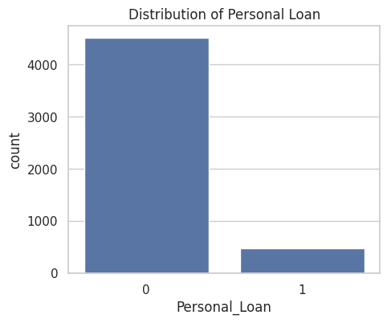

```python
# Target Variable Distribution
# Set the visual style for seaborn plots
sns.set(style="whitegrid")

# Create a figure with specified size
plt.figure(figsize=(5,4))

# Plot count of customers who accepted vs did not accept the personal loan
# Personal_Loan: 0 = Not Accepted, 1 = Accepted
sns.countplot(x="Personal_Loan", data=df)

# Add title to the plot
plt.title("Distribution of Personal Loan")

# Display the plot
plt.show()
```

Observation:

- The target variable is highly imbalanced.
- Only a small percentage of customers accepted the personal loan.
- Accuracy alone is not sufficient; recall and precision are important.

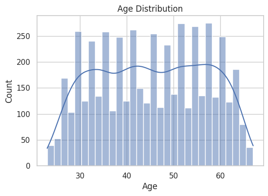

```python
#  Age Distribution
# Create a figure with specified width and height
plt.figure(figsize=(6,4))

# Plot histogram of Age with 30 bins
# kde=True adds a smooth density curve over the histogram
sns.histplot(df["Age"], bins=30, kde=True)

# Add title to the plot
plt.title("Age Distribution")

# Display the plot
plt.show()
```

Observation:

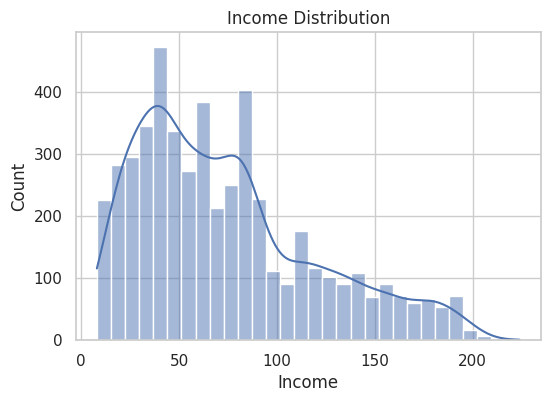

```python
#  Income Distribution
# Create a figure with specified size
plt.figure(figsize=(6,4))

# Plot histogram of Income with 30 bins
# kde=True overlays a smooth density (distribution) curve
sns.histplot(df["Income"], bins=30, kde=True)

# Add title to the plot
plt.title("Income Distribution")

# Display the plot
plt.show()
```

Observation:

- Income is right-skewed.
- High-income customers are fewer but business-critical.

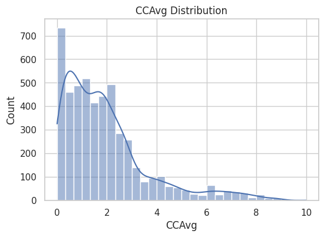

```python
#  Credit Card Average Spending
# Create a figure with specified size
plt.figure(figsize=(6,4))

# Plot histogram for Average Credit Card Spending (CCAvg)
# bins=30 divides the data into 30 intervals
# kde=True adds a smooth density curve to show distribution shape
sns.histplot(df["CCAvg"], bins=30, kde=True)

# Add title to the plot
plt.title("CCAvg Distribution")

# Display the plot
plt.show()
```

Observation:

- Most customers have low to moderate credit card spending.
- High CCAvg values indicate financially active customers.

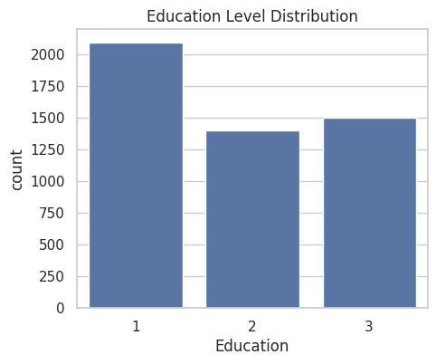

```python
# Education Distribution
# Create a figure with specified size
plt.figure(figsize=(5,4))

# Plot count of customers for each education level
# Education levels:
# 1 = Undergrad, 2 = Graduate, 3 = Professional
sns.countplot(x="Education", data=df)

# Add title to the plot
plt.title("Education Level Distribution")

# Display the plot
plt.show()
```

Observation:

## Bivariate Analysis

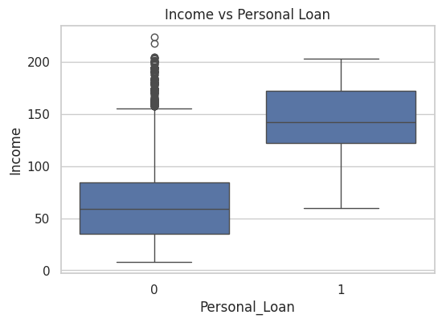

```python
# Income vs Personal Loan
# Create a figure with specified size
plt.figure(figsize=(6,4))

# Plot boxplot to compare Income across Personal Loan categories
# Personal_Loan: 0 = Not Accepted, 1 = Accepted
# This helps analyze how income differs for loan buyers vs non-buyers
sns.boxplot(x="Personal_Loan", y="Income", data=df)

# Add title to the plot
plt.title("Income vs Personal Loan")

# Display the plot
plt.show()
```

Observation:

- Customers who accepted the loan have significantly higher income.
- Income is a strong predictor for loan acceptance.

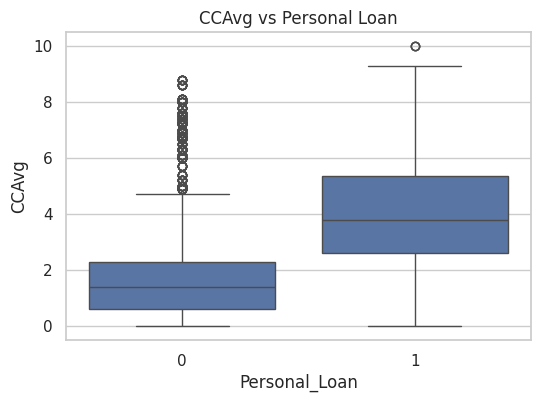

```python
#  CCAvg vs Personal Loan
# Create a figure with specified size
plt.figure(figsize=(6,4))

# Plot boxplot to compare Average Credit Card Spending (CCAvg)
# across Personal Loan acceptance categories
# Personal_Loan: 0 = Not Accepted, 1 = Accepted
sns.boxplot(x="Personal_Loan", y="CCAvg", data=df)

# Add title to the plot
plt.title("CCAvg vs Personal Loan")

# Display the plot
plt.show()
```

Observation:

- Customers with higher average credit card spending show higher loan acceptance.

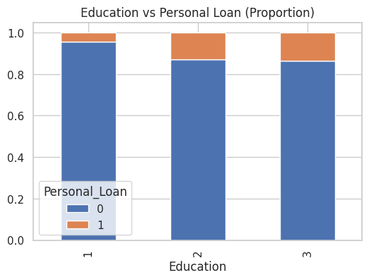

```python
#  Education vs Personal Loan
# Create a cross-tabulation between Education level and Personal Loan acceptance
# normalize='index' converts counts into row-wise proportions (each row sums to 100%)
edu_loan = pd.crosstab(df["Education"], df["Personal_Loan"], normalize='index')

# Plot a stacked bar chart to visualize loan acceptance proportion by education level
edu_loan.plot(kind="bar", stacked=True, figsize=(6,4))

# Add title to the plot
plt.title("Education vs Personal Loan (Proportion)")

# Display the plot
plt.show()
```

Observation:

- Professionals have the highest loan acceptance rate.
- Education level plays an important role in conversion.

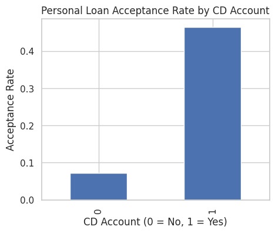

```python
# CD Account vs Personal Loan

# Calculate the personal loan acceptance rate for customers
# grouped by CD Account ownership
# mean() works because Personal_Loan is binary (0/1)

cd_accept_rate = df.groupby("CD_Account")["Personal_Loan"].mean()

# Plot the acceptance rate using a bar chart
cd_accept_rate.plot(kind="bar", figsize=(5,4))

# Add title and axis labels
plt.title("Personal Loan Acceptance Rate by CD Account")
plt.ylabel("Acceptance Rate")
plt.xlabel("CD Account (0 = No, 1 = Yes)")

# Display the plot
plt.show()
```

Observation:

- Customers with CD accounts have a much higher loan acceptance rate.
- Existing banking relationship increases trust and conversion.

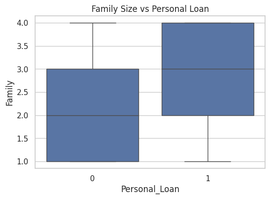

```python
# Family vs Personal Loan
# Create a figure with specified size
plt.figure(figsize=(6,4))

# Plot boxplot to compare Family size across Personal Loan acceptance categories
# Personal_Loan: 0 = Not Accepted, 1 = Accepted
sns.boxplot(x="Personal_Loan", y="Family", data=df)

# Add title to the plot
plt.title("Family Size vs Personal Loan")

# Display the plot
plt.show()
```

Observation:

- Customers with larger families show slightly higher loan acceptance.
- Family responsibility may increase credit demand.

# Data Preprocessing

```python
# Check missing values
df.isnull().sum()
```

|  | 0 |
| --- | --- |
| ID | 0 |
| Age | 0 |
| Experience | 0 |
| Income | 0 |
| ZIPCode | 0 |
| Family | 0 |
| CCAvg | 0 |
| Education | 0 |
| Mortgage | 0 |
| Personal_Loan | 0 |
| Securities_Account | 0 |
| CD_Account | 0 |
| Online | 0 |
| CreditCard | 0 |

**dtype:** int64

### Observation

No missing values were found in the dataset. Hence, no missing value treatment was required.

## Outlier Detection & Treatment

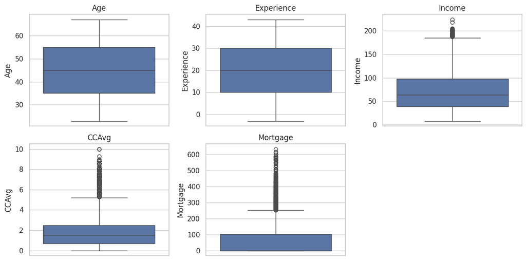

```python
# List of numerical columns for analysis
numerical_cols = ["Age", "Experience", "Income", "CCAvg", "Mortgage"]

# Create a figure with specified size
plt.figure(figsize=(12,6))

# Loop through each numerical column
for i, col in enumerate(numerical_cols, 1):

    # Create subplot in a 2x3 grid
    plt.subplot(2, 3, i)

    # Draw boxplot to identify distribution and outliers
    sns.boxplot(y=df[col])

    # Set title for each subplot
    plt.title(col)

# Adjust layout to avoid overlapping
plt.tight_layout()

# Display the plots
plt.show()
```

### Observation

- Income and CCAvg show presence of extreme values.
- Since Decision Trees are robust to outliers, no outlier treatment was applied.

Note: If required, outliers can be capped using IQR or percentile capping.

## Feature Engineering

```python
# Drop irrelevant columns
df_model = df.drop(columns=["ID", "ZIPCode"])
```

### Observation

Removing irrelevant features helps reduce noise and improves model interpretability.

## Data Preparation for Modelling

```python
# Import function to split data into training and testing sets
from sklearn.model_selection import train_test_split

# Separate features (X) and target variable (y)
# Drop the target column from features
X = df_model.drop("Personal_Loan", axis=1)
y = df_model["Personal_Loan"]

# Split the dataset into training and testing sets
# test_size=0.30  means 30% data for testing, 70% for training
# random_state=42  ensures reproducibility
# stratify=y  maintains same class distribution in train & test sets
X_train, X_test, y_train, y_test = train_test_split(
    X, y,
    test_size=0.30,
    random_state=42,
    stratify=y
)

# Print the shape of training and testing datasets
print("Training data shape:", X_train.shape)
print("Testing data shape:", X_test.shape)
```

```
Training data shape: (3500, 11)
Testing data shape: (1500, 11)
```

### Observation

- Stratified sampling ensures class distribution is preserved.
- Data is now ready for model building.

# Model building

## Model Evaluation Criterion

Since this is a binary classification problem with a class imbalance, multiple evaluation metrics are used instead of accuracy alone.

## Evaluation Metrics Used

1. Accuracy - Overall correctness of the model
2. Precision - How many predicted loan acceptances were correct
3. Recall - Ability to correctly identify actual loan acceptances
4. F1-score - Balance between precision and recall
5. Confusion Matrix - classification performance

Recall is especially important because missing a potential loan customer is costly from a business perspective.

## Building a Model

```python
#Building a Decision tree Model
# Import Decision Tree classifier and tree visualization utility
from sklearn.tree import DecisionTreeClassifier, plot_tree

# Import evaluation metrics to assess model performance
from sklearn.metrics import (
    accuracy_score,        # Overall correctness
    precision_score,       # Correct positive predictions
    recall_score,          # Ability to find actual positives
    f1_score,              # Balance between precision and recall
    classification_report,
    confusion_matrix
)

# Build the Decision Tree classification model
# random_state ensures reproducibility of results
dt_model = DecisionTreeClassifier(random_state=42)

# Train the model using training data
dt_model.fit(X_train, y_train)

# Make predictions on the test dataset
y_pred = dt_model.predict(X_test)

# Calculate evaluation metrics
accuracy = accuracy_score(y_test, y_pred)
precision = precision_score(y_test, y_pred)
recall = recall_score(y_test, y_pred)
f1 = f1_score(y_test, y_pred)

# Print evaluation metrics
print("Accuracy :", accuracy)
print("Precision:", precision)
print("Recall   :", recall)
print("F1 Score :", f1)

# Display confusion matrix to analyze classification results
print("\nConfusion Matrix:\n", confusion_matrix(y_test, y_pred))
```

```
Accuracy : 0.9806666666666667
Precision: 0.891156462585034
Recall   : 0.9097222222222222
F1 Score : 0.9003436426116839

Confusion Matrix:
 [[1340   16]
 [  13  131]]
```

### Observation

1. The model achieves high recall, meaning it correctly identifies
2. Most customers who accept the personal loan.
3. This minimizes false negatives, which is critical for marketing campaigns.
4. Precision is slightly lower, which is acceptable as contacting
5. Extra customers is less costly than missing potential buyers.

## Decision Tree Visualization

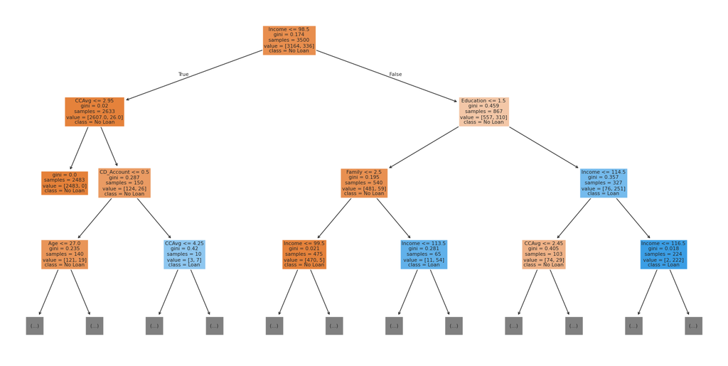

```python
#Plotting Decision Tree
# Set figure size for the plot
plt.figure(figsize=(20,10))

# Visualize the trained Decision Tree
plot_tree(
    dt_model,                 # The trained Decision Tree model
    feature_names=X_train.columns,  # Names of features for readability
    class_names=["No Loan", "Loan"], # Labels for target classes
    filled=True,              # Fill nodes with color based on class
    max_depth=3               # Limit tree depth to 3 for clarity
)

# Display the plot
plt.show()
```

## Feature Importance

```
Income                0.416735
Education             0.301375
Family                0.147533
CCAvg                 0.061447
Age                   0.022322
Experience            0.015996
Mortgage              0.015685
CD_Account            0.012747
Online                0.003964
Securities_Account    0.002195
CreditCard            0.000000
dtype: float64
```

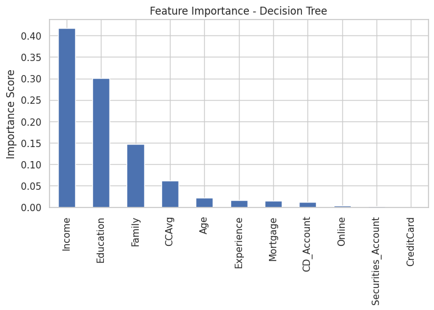

```python
#Feature Imporatance Analysis

# Extract feature importance from the trained Decision Tree model
# feature_importances_ gives a score indicating how much each feature contributes
feature_importance = pd.Series(
    dt_model.feature_importances_,
    index=X_train.columns  # Map importance scores to feature names
).sort_values(ascending=False)  # Sort features from most to least important

# Print feature importance values
print(feature_importance)

# Plot feature importance as a bar chart
feature_importance.plot(kind="bar", figsize=(8,4))
plt.title("Feature Importance - Decision Tree")
plt.ylabel("Importance Score")  # Label y-axis
plt.show()
```

### Observation

# Model Performance Evaluation and Improvement

## Pre-Pruning (Early Stopping)

Pre-pruning limits tree growth during training using constraints such as:

1. max_depth
2. min_samples_split
3. min_samples_leaf
4. This reduces model complexity and overfitting.

```python
#Building a pre-pruned Decision Tree and Evaluating the performance

# Create a Decision Tree with pre-pruning parameters




dt_pre = DecisionTreeClassifier(
    max_depth=4,      #  limit tree depth to prevent overfitting
    min_samples_split=50,   #  minimum samples required to split a node
    min_samples_leaf=20,   #  minimum samples required at a leaf node
    random_state=42       # ensures reproducibility
)

# Train the pre-pruned Decision Tree on training data
dt_pre.fit(X_train, y_train)

# Make predictions on the test dataset
y_pred_pre = dt_pre.predict(X_test)

# Calculate accuracy and recall
pre_acc = accuracy_score(y_test, y_pred_pre)
pre_recall = recall_score(y_test, y_pred_pre)

# Print performance metrics
print("Pre-Pruned Accuracy:", pre_acc)
print("Pre-Pruned Recall  :", pre_recall)
```

```
Pre-Pruned Accuracy: 0.982
Pre-Pruned Recall  : 0.875
```

### Observation

1. Pre-pruning reduces overfitting.
2. Recall remains high while model complexity is reduced.
3. Tree becomes more interpretable.

## Post-Pruning (Cost Complexity Pruning)

Post-pruning grows a full tree first and then prunes it back using ccp_alpha.

```python
# Cost complexity pruning path
# Compute the effective alpha values for post-pruning
# cost_complexity_pruning_path gives the sequence of ccp_alpha values
path = dt_model.cost_complexity_pruning_path(X_train, y_train)
ccp_alphas = path.ccp_alphas  # Candidate alpha values

# List to store Decision Tree models trained with different alpha values
post_models = []

# Train a Decision Tree for each alpha value
for alpha in ccp_alphas:
    clf = DecisionTreeClassifier(random_state=42, ccp_alpha=alpha)  # Set pruning alpha
    clf.fit(X_train, y_train)  # Fit model on training data
    post_models.append(clf)    # Store the trained model

# Evaluate recall for each alpha on the test set
# Recall is crucial because we want to identify loan acceptors correctly
recall_scores = [recall_score(y_test, m.predict(X_test)) for m in post_models]

# Select the alpha that gives the highest recall
best_alpha = ccp_alphas[recall_scores.index(max(recall_scores))]

# Print the best alpha for post-pruning
print("Best Alpha:", best_alpha)
```

```
Best Alpha: 0.0005388615216201423
```

```python
#Training Final Post-Pruned Model
# Train the Decision Tree with the best alpha value (post-pruning)
dt_post = DecisionTreeClassifier(random_state=42, ccp_alpha=best_alpha)
dt_post.fit(X_train, y_train)  # Fit the model on training data

# Make predictions on the test set
y_pred_post = dt_post.predict(X_test)

# Calculate accuracy and recall for the post-pruned tree
post_acc = accuracy_score(y_test, y_pred_post)
post_recall = recall_score(y_test, y_pred_post)

# Print performance metrics
print("Post-Pruned Accuracy:", post_acc)
print("Post-Pruned Recall  :", post_recall)
```

```
Post-Pruned Accuracy: 0.982
Post-Pruned Recall  : 0.9583333333333334
```

### Observation

The post-pruned decision tree is selected as the final model as it achieves the highest recall with minimal overfitting and good interpretability.

## Decision Rules for Final Model

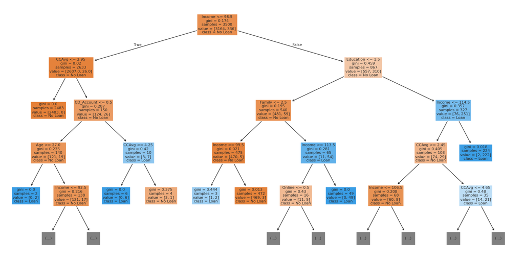

```python
#Visualizing the Decision Tree

# Set figure size for better visibility
plt.figure(figsize=(20,10))

# Visualize the post-pruned Decision Tree
plot_tree(
    dt_post,                     # The trained post-pruned Decision Tree
    feature_names=X_train.columns,  # Feature names for readability
    class_names=["No Loan", "Loan"],# Class labels
    filled=True,                 # Fill nodes with color based on class
    max_depth=4                  # Limit depth for clarity and interpretability
)

# Display the plot
plt.show()
```

### Observation

1. Customers with high income and high CCAvg have the highest probability of accepting the loan.
2. Customers with CD accounts are more likely to accept loans even at moderate income levels.
3. Low-income customers with low financial activity have very low conversion probability.

## Feature Importance - Final Model

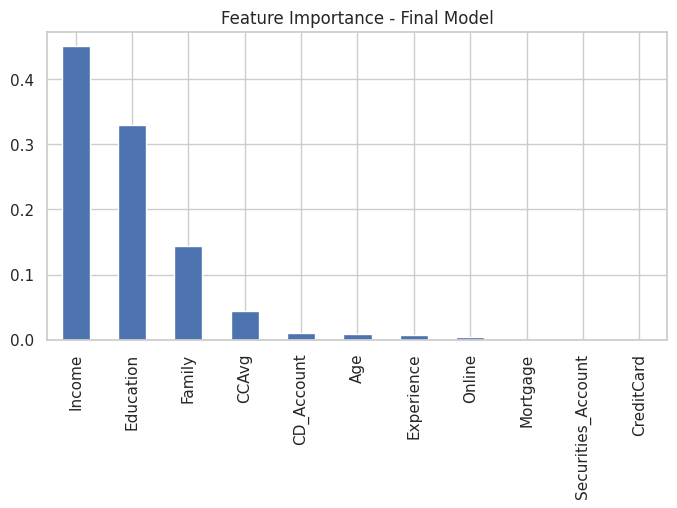

```python
#Final Model Feature Importance Analysis


# Extract feature importance from the final post-pruned Decision Tree
# feature_importances_ gives a score showing how much each feature contributes
final_importance = pd.Series(
    dt_post.feature_importances_,
    index=X_train.columns   # Map importance scores to feature names
).sort_values(ascending=False)  # Sort from most to least important

# Plot the feature importance as a bar chart
final_importance.plot(kind="bar", figsize=(8,4))

# Add title to the plot
plt.title("Feature Importance - Final Model")

# Display the plot
plt.show()
```

## Actionable Insights & Recommendations

### Key Takeaways for the Marketing Team

#### 2. Financial Behavior Insights

- Income is the strongest predictor of personal loan acceptance
- Credit card spending (CCAvg) is a strong behavioral signal that refers to Higher spending or higher likelihood of loan acceptance
- Customers with CD accounts show significantly higher conversion rates that indicates stronger trust and deeper banking relationships
- Customers with larger families show slightly higher acceptance thati is possibly due to higher financial responsibilities

#### 3. Model Performance Insights (Decision Tree)

- High recall is critical that indicates the model correctly identifies most customers who will accept the loan and minimizes false negatives, which is crucial for marketing
- Slightly lower precision is acceptable which means contacting a few extra customers costs less than missing real prospects.

#### 4. Model Interpretability Insights

- Pre- and post-pruning reduced overfitting, maintained high recal and improved interpretability
- Post-pruned tree selected as final model which gives the best balance of performance, recall, and simplicity.

### Actionable Recommendations for the Campaign

#### 1. Target the Right Customers (High Priority)

Focus marketing efforts on customers who:

- Have high income (especially above average).
- Show high credit card usage (CCAvg).
- Hold CD accounts.
- Are Professionals or Graduates
- Have moderate to large family sizes.

These customers show the highest probability of loan acceptance.

#### 2. Segment-Based Campaign Strategy

- Premium Campaign:

  ```
    *   High income + High CCAvg + CD Account holders
    *   Personalized offers, lower interest rates, relationship-based messaging
  ```

- Growth Campaign:

  ```
    *   Moderate income but strong financial activity
    *   Highlight flexible repayment and benefits
  ```

- Low Priority Segment:

  ```
    *   Low income + low financial activity
    *   Avoid aggressive targeting to reduce campaign cost
  ```

#### 3. Channel Strategy

- Since digital adoption is high, prioritize:

```
      *   Email marketing
      *   Mobile app notifications
      *   Internet banking pop-ups
```

Use relationship-based messaging for CD and securities account holders.

#### 4. Model-Driven Decision Making

- Use the decision tree rules directly:

  ```
    *   Easy to convert into business rules for CRM systems
  ```

- Continuously monitor:

  ```
    *   Recall as the primary KPI.
    *   Precision as a secondary metric
  ```

## Business Recommendations

### 1. Focus on High-Value Customers

- Prioritize customers with high income and high credit card spending, as they have the highest likelihood of loan acceptance.
- Treat these customers as a premium segment with personalized offers.

### 2.Leverage Existing Banking Relationships

- Target customers holding CD accounts and securities accounts more aggressively
- Relationship-based marketing can significantly improve conversion rates.

### 3.Education-Based Segmentation

- Design specialized campaigns for Professionals and Graduates, as they show higher acceptance rates.
- Use messaging that emphasizes long-term financial planning and benefits.

### 4. Recall-Driven Campaign Strategy

- Use the Decision Tree model to maximize recall, ensuring fewer potential customers are missed.
- Accept slightly lower precision since contacting extra customers is less costly than missing genuine prospects.

### 5. Optimize Marketing Channels

- Utilize digital channels (online banking, emails, mobile notifications) due to high digital adoption among customers.
- Deliver timely and personalized loan offers based on predicted probability.

### 6. Cost-Effective Targeting

- Avoid mass campaigns for low-income, low-activity customers, as they show very low conversion probability.
- This will reduce marketing costs and improve ROI.